# Pokročilé datové struktury a algoritmy

### Hladové heuristiky

Hladové heuristické algoritmy, vycházejí z lokálních rozhodnutí, nemusí však najít skutečné globální optimum. I když ve většině případů najdou řešení, které je akceptovatelnou aproximací, existují úlohy a vstupy, pro něž určité heuristické algoritmy najdou jen špatná řešení (což jsou řešení, které jsou horší než náhodný přístup).

Heuristické algoritmy nacházejí uplatnění především v případech, kdy neexistuje řešení s polynomiální časovou složitostí, které je aplikovatelné jen na soubory s malým počtem dat. Typickým příkladem je [problém obchodního cestujícího](https://en.wikipedia.org/wiki/Travelling_salesman_problem). Tento problém je NP-úplný, polynomiální algoritmus tudíž není znám a pravděpodobně ani neexistuje.

Základní heuristický algoritmus využívají i ti nejhloupější obchodní cestující: stačí vždy cestovat do nejbližšího nenavštíveného města (přičemž počáteční město je zvoleno náhodně, např. je to bydliště daného obchodního cestujícího). Tato heuristika vede v praktickém životě k akceptovatelným výsledkům (viz výsledek zdroje [22] na Wikipedii, který uvádí průměrné prodloužení o 25%).

Zajímavější heuristikou problémů obchodného cestujícího je využití optimalizace mravenčí kolonie, viz například implementaci na [GitHubu](https://github.com/rochakgupta/aco-tsp).

#### Barvení grafu

Jedním z nejtypičtějších a nejpraktičtějších využití hladové heuristiky je barvení grafu. I když v případě https://mathworld.wolfram.com/VertexColoring.html existuje velké množství poznátků o optimálním barvení (optimální barvení uzlů využívá mimimální počet barev, což je tzv. chromatické číslo $\chi(G)$) neexistuje žádný efektivní algoritmus, který by pro libovolný graf našel optimální obarvení jinak než hrubou silou (přirozeně s exponenciální složitostí).

Nejčastěji se tak používá heuristika, která využivá hladový přístup. V nejjednodušším případě se stanoví nějaká posloupnost uzlů a v této posloupnosti se každý uzel obarví nejmenší možnou barvou (tj. předpokládá se že barvy jsou representovány přirozenými čísly).

Implementace této heuristiky je uvedena přímo v příslušném článku Wikipedie [Greedy coloring](https://en.wikipedia.org/wiki/Greedy_coloring).

> **Úkol**: Ověřte různé strategie pořadí uzlů podporované funkcí zajišťující barvení hladovou heuristikou v knihovně *NetworkX* (viz https://networkx.github.io/documentation/stable/reference/algorithms/coloring.html). Vyzkoušejte pro náhodné grafy, či grafy speciální bipartitní, rovinné apod.

> **Úkol (k zamyšlení)**: Implementace funkce vracející nejmenší nepoužité číslo (tj. barvu nepoužitou sousedními uzly) je dosti neefektivní. V případě použití menších čísel (což lze u reálně použitelných grafů očekávat) lze využít bitovou aritmetiku. Zkuste najít příslusné řešení (rada: identifikace nejnižšího nenulového bytu a použití slovníku).

## Další algoritmy využívající lokální rozhodování

### Triviální řadící algoritmy

Jako triviální řadící algoritmy se označují řadící algoritmy, které mají časovou složitost $O(n^2)$ (tj. jejich časová složitost odpovídá porovnání každého prvku seznamu se všemi ostatními prvky).

Pro třídění větších polí nepředstavují konkurenci pro algoritmy založené na přístupu rozděl a panuj s časovou složitostí $O(n\log(n))$.

V praxi se však některé z nich mohou uplatnit ve specifických situacích:

- *malé kolekce (řádu malých desítek) = algoritmy* insertion sort *a v menší* selection sort* jsou pro malé kolekce efektivnější než komplexní algoritmy (často se používají pro třídění listových úloh v přístupu rozděl a panuj)
- *snižení počtu výměn či zápisů* = algoritmus *selection sort* a především *cycle sort* minimalizují počet záměn a tím i poče zápisů. To je výhodné,pokud je zápis výrazně pomalejší než čtení neb je počet zápisů omezen (flash paměti, EPROM paměti)

> **Úkol**: Nastudujte výše uvedené řadící algoritmy a porovnejte jejich efektivitu pro malá pole.

### Prohledávání v grafech

Klasickými algoritmy nad grafy využívajícími lokální volbu jsou algoritmy, které prohledávají všechny uzly dostupné z určitého uzlu (tj. v případě neorientovaného grafu celou komponentu).

Tuto třídu algoritmů lze využívat pro stromy i pro obecné grafy a lze je využívat pro různé účely od hledání nejkratších cest (= nejmenšího počtu procházených hran), přes zjišťování komponent po hledání různých charakteristik konektivity.

Dva základní algoritmy procházení grafů je prohledávání do šířky (breadth-firts) a do hloubky (depth-first).

Popis obou algoritmů můžete najít na https://www.educative.io/edpresso/how-to-implement-depth-first-search-in-python resp. https://www.educative.io/edpresso/how-to-implement-a-breadth-first-search-in-python.

> **Úkol**: Implementujte algoritmus nad representací grafů použitou v knihovně NetworkX a porovnejte s implementací, která je již hotová v knihovně Networkx.

> **Úkol+**: Rozšiřte algoritmus tak, aby rozlišil stromové, dopředné, zpětné a příčné hrany nad kostrou definovanou prohledáváním do hloubky (popis viz např. https://cw.fel.cvut.cz/old/_media/courses/a7b33tin/02_pruchod_grafem.pdf).

# 6. Algoritmy využívající náhodnost (pravděpodobnostní algoritmy)

Algoritmy využívající náhodnost se využívají v případech, kdy je dosažení určitého *optimálního řešení* neefektivní a postačuje jen řešení, které je pouze řešením přibližným (heuristické algoritmy), ale také v případech, kdy zahrnutí náhodnosti neovlivňuje výsledek, ale pouze efektivitu algoritmu. Algoritmus tak dosahuje „průměrné“ časové či paměťové složitosti bez ohledu na vstupní data. To je důležité především v případě, kdy je nejhorší časová složitost jiné třídy (průměr není jednoduchým aritmetickým průměrem) a kdy je pravděpodobnost výskytu kritických dat (= dat vedoucích k vyšší asymptotické složitosti) vysoká.

Příkladem elementární heuristiky je např. výpočet průměrů, který běžně vyžaduje součet všech prvků v kolekci (časová složitost je tedy $O(n)$). Pro zjištění odhadu průměru však stačí sečíst jen $k$ vybraných čísel (kde $k$ je konstanta $\ll n$), jehož časová složitost je konstantní. Je to stejný přístup, který se běžně používá ve statistickém šetření, které se provádí jen na malém vzorku populace (statistika nám při splnění určitých předpokladů dává i chyby takových odhadů).

Nejdříve se však podíváme na zdroj náhodných čísel tzv. generátory.

## Hardwarové generátory náhodných čísel

Jádrem pravděpodobnostních algoritmů je získání náhodného proudu bitů s rovnoměrným rozdělením (tj. každý bit proudu má stejnou pravděpodobnost hodnoty 0 resp. 1) tj. například neexistuje žádná závislost mezi libovolnými dvěma bity (tj. například pravděpodobnost hodnoty v n-bitu není ovlivněna tím že $i*n$ bity pro $i\in{1..5}$ jsou jedničkové).

Získání skutečně náhodných posloupností je velmi obtížné. I když je podle našeho současného fyzikálního modelu produkují některé kvantové procesy, je jejich získávání technicky dosti obtížné (včetně nutnosti transformací, pokud nemají rovnoměrné rozložení). Prakticky se proto používá šum, který vzniká překrýváním většího počtu kvantových procesů (termální šum, fotoelektrický efekt a podobně).

Reálný generátor využívající radioaktivníh rozpad cesia $^{137}\mathrm{Cs}$ můžete najít na adrese https://www.fourmilab.ch/hotbits/.

V případě pravděpodobnostních algoritmů však hardwarové zdroje nehrají téměř žádnou úlohu, neboť jsou:

1. příliš pomalé (tj. čas produkce náhodných čísel nelze zanedbat, výše uvedený generátor například `hotbits` produkuje jen cca 100 bytů/s)
2. nejsou reprodukovatelné (a tudíž obtížněji laditelné).

Hardwarové generátory náhodného bitového proudu je však nutno použít tehdy, pokud hrozí nebezpečí, že zpracovávaná data mohou být vědomě ovlivněna, tak aby s predikovanými reprodukovatelnými "náhodnými" hodnotami pravděpodobnostní hodnoty vracely chybné výsledky resp. spotřebovával enormně mnoho prostředků.

Útočník může například přeuspořádat vstupní pole tak, že operace `shuffle` (proházení prvků) nevrátí (zdánlivě) náhodný mix prvků, ale seřazené pole. Pokud na toto pole použijeme `quicksort` je to nejen nadbytečné, ale může vést k tomu že časová složitost algoritmu může dosáhnout $O(n^2)$, což může tuto operaci výrazně zpomalit. I když se útoky tohoto typu mohou jevit v této oblasti jako nerealistické, nelze je vyloučit v případě, kdy suboptimální výkonnost může snížit dostupnost nějaké služby. V tomto případě je nutno na reprodukovatelnost rezignovat (klíčová je jen ve fázi ladění) a použít hybridní přístup (hardwarově generovaný proud slouží pro občasnou inicializaci softwarových generátorů).

V operačním systému Unix lze pro tyto účely využít objekt třídy `random.SystemRandom`, který spojuje softwarový generátor se zdroji tzv. entropie (= zdroje šumu + hardwarové generátory, které jsou dnes k dispozici i v rámci běžných CPU).

> **Upozornění**: I když tento generátor není reálně reprodukovatelný, jeho použití pro kryptografické účely není doporučováno (Python poskytuje pro kryptografické účely modul `secrets`)

```python
from random import SystemRandom

generator = SystemRandom()
print(bin(generator.getrandbits(1024))) # využívá systémový generátor náhodných bitů pro získání produ 1024 bitů (= 128 bytů)
```

```
0b1010010010100000010111000001110111111000010010111111101000…
```

## Transformace na posloupnost čísel

Než přejdeme k softwarovým generátorům je nutno prodiskutovat mapování proudu bitů na proud náhodných čísel a to jak celých (typu `int`) tak čísel pohyblivou řádovou čárkou (typ `float`). Nejjednodušší situace je v případě celých čísel v rozsahu 0 (včetně) až $2^n$ (vyjma). Zde stačí vzít $n$ bitů a interpretovat je jako číslo. V případě, že výsledkem mají být celá čísla v jiném rozsahu, je nutný přepočet tj. například aplikace operace zbytku po dělení (pokud má být výsledkem celé číslo) resp. dělení. Ti však má ve většině případů bohužel tyto negativní důsledky:

- výsledné rozdělení čísel nemusí být rovnoměrné
- při transformaci se zahazují určité bity (tento nedostatek nemá vliv na výsledky pravděpodobnostních algoritmů, snižuje však jejich efektivitu)
- používají neefektivní operace (například transformaci mezi celými čísly a čísly v řádové čárce)

Elementární přístupy jako je vedou vždy k alespoň jednomu z výše uvedených negativních důsledků a často i ke dvěma.

> **Úkol**: Navrhněte triviální a implemntujte algoritmus pro generování celých čísel v rozsahu 0 až $n$, na základě možnosti generovat libovolnou posloupnost náhodných bitů (viz výše metoda `getrandbits`). Diskutujte řešení.

Nejjednoduší přístup je výpočet podle vztahu `i % n`, kde i je náhodné číslo v rozsahu 0 az $2^k$, přičemž $2^k > n$.

Je-li $2^k = n$: triviální případ, řešení je přesné a rychlé i úsporné (není potřeba ani provádět zbytek po dělení)

Je-li $2^k$ řádově shodné s $n$: například $n=6$ a $k$ je 3, 4, apod., pak je výpočet efektivní, ztrácí se jen pár bitů ale výsledné rozložení pravděpodobnosti není rozhodně rovnoměrné. Při volbě $k=3$ budou mít čísla 0 a 1 dvakrát vyšší pravděpodobnost než čísla 2 až 5 (tj. simulovaná kostka bude viditelně nepřející).

Alternativně lze využít vypočet prostřednictvím typu float v podobě `int(i/(2**k)*n`, která trpí stejnými vadami (např. pro nízké hodnoty `2^k` je rozdělení podobně nepravidelné, i když méně zřejmé). Využití dělení v plovoucí řádové čárce a přetypování na `int` může být značně neefektivní (především pokud cílová platforma postrádá efektivní hardwarové [FPU](https://en.wikipedia.org/wiki/Floating-point_unit).

> **Úkol**: vypočítejte rozdělení pravděpodobnosti hodnot 0-5 vypočítaných pomocí vztahu, kde $k=3,8,16,32$ (tj. nejmenší možné a o délce slov běžných procesorů). Zamyslete se nad výsledkem (jak nepravidelnosti tolerovatelné, resp, v jakých kontextech)

```
3 [(0, 25.0), (3, 25.0), (1, 12.5), (2, 12.5), (4, 12.5), (5, 12.5)]
```

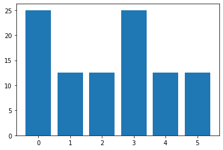

```
8 [(0, 16.796875), (1, 16.796875), (3, 16.796875), (4, 16.796875), (2, 16.40625), (5, 16.40625)]
```

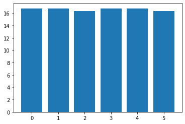

```
16 [(0, 16.66717529296875), (1, 16.66717529296875), (3, 16.66717529296875), (4, 16.66717529296875), (2, 16.6656494140625), (5, 16.6656494140625)]
```

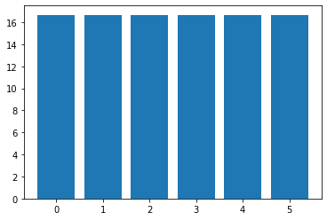

```python
from collections import Counter
from matplotlib.pyplot import bar, show

for k in [3,8,16]:
    nk = 2**k
    c = Counter(int(i/nk*6) for i in range(nk))
    h = [(n, 100*p/nk) for n,p in c.most_common()]
    x,y = zip(*h)
    print(k, h)
    bar(x,y)
    show()
```

## Softwarové generátory pseudonáhodných čísel

Sigtwarové generátory produkují náhodná čísla tím, že interně udržují nějaký stav (pole bytových hodnot), na který je možno aplikovat funkci $t_s$, která vrátí nový stav.

$S_{i+1} = t_s(S_i)$, kde $i \geq 0$

Počáteční hodnota $S_0$ se se získává transformací ($t_i$) z hodnoty nazývané inicializační (*random seed*), která může být buď fixní (umožňujíc reprodukovatelnost), měnit se s časem (typicky je to např. některá z representací reálného času) nebo to může být náhodná hodnota získaná hardwarovým generátorem.

Aplikací další funkce $t_r$ na jednotlivé stavy pak získáváme postupně bloky pseudonáhodných bitů (které jsou typicky chápány jako čísla)

$r_i = t_r(S_i)$

Ze zjednodušeného předpisu je zřejmé, že výsledkem aplikace softwarového generátoru nemůže být skutečně náhodná posloupnost bitů resp. čísel. Neboť hodnoty $r_i$ jsou evidentně závislé na předchozích stavech resp. na inicializační hodnotě (lze je tudíš snadno znovu reprodukovat). Navíc se hodnoty musí cyklicky opakovat (stav je representovaný konečým polem bitů a tak existuje jen konečný počet stavů).

Na druhou stranu nelze v mnoha případech (a v konečném a rozumném čase rozlišit) mezi posloupností genrovanou hardwarovým generátorem a posloupností generovanou generátorem softwarovým, neboť:

1. perioda po níž se čísla cyklicky opakují je mimořádně dlouhá
2. hodnoty jsou rovnoměrně rozloženy (tj. nelze statisticky dokázat, že existuje nějaký bias)
3. libovolné dostatečně velké nepřekrývající se výběry nejsou korelované (to platí i pro hodnoty, které následují bezprostředně či blízko za sebou)
4. vzdálenosti mezi opakujícími se vzory mají stejnou distribuci jako v případě skutečně náhodných posloupností
5. hodnoty jsou rovnoměrně distribuovány i ve více dimenzích (tj. body s s pseudonáhodně gnerovanými souřadnicemi vyplňují rovnoměrně každý či alespoň daný $n$-dimezionální prostor).

### Lineární kongruentní generátory

Nejjednoduššími softwarovými generátory jsou lineární kongruenční generátory, u nichž je následující číslo generováno předpisem:

$x_{i+1}=(ax_{i}+c)\ {\bmod {\ }}m$, kde $a$, $c$ a $m$ jsou vhodně zvolená přirozená čísla.

I když jsou známy základní požadavky na volbu čísel, které mimo jiné zajistí, že cyklus bude mít maximální délku $m-1$, je nalezení skutečně optimálních čísel spíše empirickou úlohou. Navíc je výhodné, pokud $m$ odpovídá šířce slova (tj. je rovna např. 2^32 u 32-bitových procesorů), neboť to usnadňuje implementaci zbytku po dělení (operace modulo je eliminována neboť všechny výpočty nativně probíhají v modulární aritmetice $2^n$, tj. vyšší bity výsledku jsou automaticky ignorovány) a/nebo $c$ c je rovno nule (eliminace sčítání) resp. 1 (inkrementace je na některých architektur efektivnější než obecný součet). Lineárně kongruentní generátory jsou proto obecně velmi rychlé (tím spíše pokud architektura podporuje rychlou operaci multiply-accumulation).

**Poznámka**: Některé volby parametrů vedou k tomu, že některé bity mají nižší periodicitu a tak je nutno ze stavu extrahovat jen některé bity (typické především tehdy je-li parametr $c$ nulový).

> **Úkol**: implementujte tři typické lineární kongruenční operátory a diskutujte jejich použitelnost.
> - klasická implementace operace random v jazyce C: a = 1103515245, c = 12345, m = 2^31 (typicky se používá bity vyšší bity (16-30).
> - minimalistická implementace (CRAY RANF): a = 44 485 709 377 909, c = 0, m = 2^48 - 1
> - katastrofická implementace (RANDU): a = 65539, c = 0, m = 2^31

> *Otázka pro zvídavé*: Aditivní člen v prvním příkladě má hodnotu 12345. Je to z důvodu, že implementátory jiné „náhodné“ číslo nenapadlo?

```python
from itertools import islice
def lcg(modulus, a, c, seed):
    """Linear congruential generator.
    source: https://en.wikipedia.org/wiki/Linear_congruential_generator"""
    while True:
        seed = (a * seed + c) % modulus
        yield seed

for number in islice(lcg(2**31, 1103515245, 12345, 0), 12):
    print(f"{number:032b}")
```

```
00000000000000000011000000111001
01010011110111000001011001111110
00100111000001000010011111011111
01010110011001010001110000101100
00001101101010101001011011110101
01000010000111110001110010001010
00111110101011010110001011111011
01001101000111011100111100011000
00101111010110101010110101110001
00100000110110100111011101010110
00101111111001010011001111010111
01101001101011001100010011000100
```

Linearní kongruentní generátory jsou vhodné, jen tehdy pokud:

- implementace musí využívat jen velmi omezené prostředky (např. na známých [Arduinech](https://www.arduino.cc/reference/en/language/functions/random-numbers/random/) s pár KiB paměti a pomalými aritmetickými operacemi)
- postačuje menší počet generovaných čísel (což často neplatí u Monte Carlo algoritmů!), u 32 bitové implementace je vhodný například pro řády tisíců náhodných hodnot
- jsou využívány jen vyšší bity stavu (což ale snižuje jejich efektivitu). Zvlášť problematický je nejnižší bit (viz příklad výše)

### Mersenne twister a PCG gnerátory

Nejpopulárnějšm algoritmem dneška je tzv. Mersenne twister, který využívá mnohem větší representaci stavů a řeší většinu problémů LCG generátorů. Zvláště efektní je extrémně dlouhá perioda, která u běžně používané konfigurace dosahuje $2^{19937}-1 \approx 10^6000$, což by mělo stačit po celou zbývající dobu existence lidské civilizace.

Na druhou stranu má více parametrů, které je nutno pečlivě volit, vyžaduje více paměti a je pomalejší (i když nikoliv řádově).

Mersenne twister je standardním softwarovým generátorem, používaným v pythonském modulu `random` (platné pro Python 3.8 a starší verze Pythonu 3) a to hned k několika účelům:

1. generování posloupnosti náhodných bitů `random.getrandbits`
2. generování náhodných celých čísel z určitého rozsahu (`random.randint` resp. `random.randrange`)
3. náhodný výběr ze seznamu (`random.choices` nebo `random.sample` resp. specializované `random.choice`)
4. náhodná permutace prvků seznamu (`shuffle`)
5. generování čísel v pohyblivé řádové s rovnoměrným rozdělením čárce z intervalu $[0, 1)$ (`random.random`) resp. z intervalu $[a, b]$ (`random.uniform`)
6. generování čísel v jinách spojitých rozděleních (včetně normálního a ecponenciálního, viz níže)

Jediné, co funkce z modulu `random` přímo nenabízí je generování kolekcí hodnot (to lze samozřejmě zajistit opakovaným voláním, ale to je neefektivní). V tomto případě je vhodnější využít modul `numpy.random`.

Při použití tohoto modulu je možno (od verze 1.18) využít dvou přístupů:

- starší (klasický) přístup (jednoduché volání funkcí, jejichž jediným parametrem je tvar výsledného pole), modul nabizí velké množství funkcí pro různé typy výstupů, různá rozdělení (a to v často v různých variantách, aby bylo dosaženo kompatibility s jiným matematickým softwarem). Základním generátorem je klasický Mersenne twister.
- nový přístup (oddělení bitového generátoru a generátoru čísel), přehlednější a ortogonálnější rozhraní, explicitní podpora pro vytváření nezávislých generátorů v paralelních aplikacích (tzv. spawning). Navíc nabízí jako standardní základní (bitový) generátor relativně nový PCG64 generátor, který by měl mít lepší statistické vlastnosti při využití méně prostředků (včetně času). Pro ty, kteří novinkám nevěří, je k dispozici standardní Mersenne Twister.

Popis PCG generátorů naleznete na stránce https://www.pcg-random.org/index.html. Obsahují i zajímavý úvod ke statistickému testování generátorů a také diskutují silné i slabé stránky většiny v současnosti využívaných generátorů.

> **Úkol**:
> 1. vyplňte seznam 100 náhodnými hodnotami typu `int` z intervalu 1 .. 100 (s využitím jediného příkazu a klasické knihovny `random`)
> 2. vyplňte matici 100×100 náhodnými hodnotami typu `float` z intervalu $[-100, 100]$ (s využitím starého i nového rozhraní v NumPy).

## Generování náhodných hodnot z jiných rozdělení

Častým požadavkem je generování pseudonáhodných čísel z jiného než rovnoměrného rozdělení (typicky jsou to spojitá rozdělení a generována jsou tak čísla typu `float`). Pro tyto účely existují dva přístupy, které se typicky kombinují. Oba využívají jako zdroj generátor s náhodným rozdělením vracející čísla `float` z určitého intervalu (standardně $[0, 1)$).

1. na hodnoty je applikována nějaká (nelineární) funkce
2. některé hodnoty jsou zahozeny, tak aby měl výsledný generátor příslušné rozdělení

V případě rozumných generátorů je transformační funkce jednoduchá (a tudíž rychlá) a počet zahozených hodnot malý (v opačném případě by algoritmus produkoval jen málo čísel za časovou jednotku a zpomaloval by tak příslušný prevděpodobnostní algoritmus).

V minulosti se používalo velké množství různých algoritmů. Dnes se však využívá tzv. zikkurat algoritmus, pojmenovaný podle mezopotámských městských chrámů.

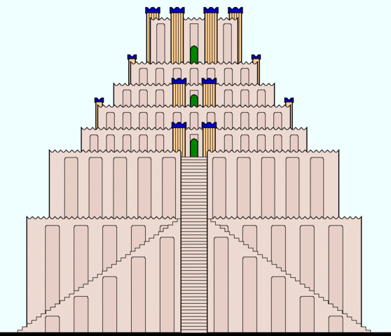

Přehledný a přitom dostatečně detailní popis algoritmu (pro normální rozdělení) najdete na https://heliosphan.org/zigguratalgorithm/zigguratalgorithm.html (naleznete tam i obrázek, který vysvětluje název algoritmu). Algoritmus je elegantní a jednoduchý vyjma speciálního ošetření tzv. ocasu (část křivky hustoty rozdělení, kde je hodnota hustoty pravděpodobnosti nízká, ale nikdy nedosáhne nuly).

> **Úkol**: Implementujte zikkurat algoritmus pro symetrické [trojúhelníkové rozdělení](https://en.wikipedia.org/wiki/Triangular_distribution) (tj. modus leží uprostřed mezi krajními body, vně jichž je hustota pravděpodobnosti nulová).

```python
def triangle_rnd(a, b):
    m = (a+b)/2
    ...
```

> **Úkol**: Vygenerujte 1000 bodů s exponenciálním rozdělení se střední hodnotou 0.5 a zobrazte jejich histogram (s krokem 0.1) a proložte ho teoretickou křikvkou hustoty

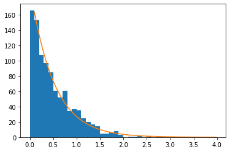

```python
import numpy as np
from numpy.random import exponential
import matplotlib.pyplot as plt

λ = 1/0.5 # 1 / střední hodnota
step = 0.01
n = 1000
sample = exponential(1/λ, n) # zadává se střední hodnota tj. 1/λ
plt.hist(sample, bins=np.arange(0, 4, 0.1))
x = np.arange(0.1, 4, step)

plt.plot(x, λ*np.exp(-λ*x) / step)
plt.show()
```

> **Poznámka a úkol**: Výše uvedený přístup lze použít i obráceně. Mějme generátor binárních hodnot, který má tzv. bias tj. častěji generuje jedno ze dvou binárních čísel častějí (tj. s pravděpodobností $p \neq 0.5$). Implementujte řešení ze stránky https://www.geeksforgeeks.org/print-0-and-1-with-50-probability/ a diskutujte ho.

## Randomizované verze standardních algoritmů

Jedním z využití generátoru pseudonáhodných čísel je tzv. randomizované verze algoritmů, tj. verze v nichž dochází buď k randomizaci vstupu resp. k randomizaci nějakého kroku algoritmu.

Prvním příkladem je randomizace vstupu při vytváření binárního stromu. Tato strategie je vhodná v případě, že ukládáno je velké množství dat najednou a přidávání jednotlivých dat je jen výjimečné.

Algoritmus se v tomto případě nemění, vstupní data však musí být dočasně uložena v poli či seznamu a náhodně promíchána (*shiffling*).

Nejčastěji používaným algoritmem používaným pro náhodné promíchání je algoritmus **Fisher-Yattesův**, který nabízí promíchání s časovou složitostí $O(n)$ a probíhá přímo ve zdrojovém poli {*in-place*).

> **Úkol:** Prostudujte moderní verzi Fisher-Yettesova algoritmu na https://en.wikipedia.org/wiki/Fisher%E2%80%93Yates_shuffle (velmi kvalitní Wikipedia článek, diskutující i jiné přístupy a také úskalí, které může být dáno např. použitím nedokonalého generátoru náhodných čísel). Algoritmus efektivně implementujte.

```python
from random import randrange

def shuffle(data): # implementace v čistém pythonu
    n = len(data)
    for i in range(0, n):
        j = randrange(i, n)
        data[i], data[j] = data[j], data[i]
    return data

print(shuffle(list(range(42))))
```

```
[26, 41, 7, 39, 37, 40, 22, 23, 32, 15, 8, 38, 36, 24, 29, 10, 0, 12, 28, 30, 35, 3, 11, 18, 27, 31, 19, 13, 2, 17, 9, 4, 1, 20, 21, 33, 25, 6, 5, 16, 14, 34]
```

Fisher-Yattesův algoritmus je přirozeně implementován i v ve standardní knihovně Pythonu (`random.shuffle`) i v Numpy pro pole (`numpy.random.shuffle`).

> **Úkol k zamyšlení**: V případě jednorázové inicializace vyhledávacího stromu (tj. jedno vkládání, mnoho vyhledávání) lze alternativně využít setřídění a následné využití binárního vyhledávání. Diskutujte prostorovou a časovou složitost.

Příkladem interně ranodmizovaného algoritmu je `quicksort` s náhodným výberem pivota. Stránka https://www.geeksforgeeks.org/quicksort-using-random-pivoting/ obsahuje dvě různé implementace využívající různá schémata dělení (porovnejte!).